Connected to ccaes_dashboard (Python 3.10.11)

# Understanding Participation Patterns: Classifying MA-User Behavior

```python
from typing import List, Optional
from functools import partial
import warnings

import matplotlib.pyplot as plt
import pandas as pd
import seaborn as sns
from matplotlib import ticker
from sklearn.cluster import SpectralClustering, AgglomerativeClustering
from scipy.spatial import distance
from sklearn.preprocessing import Normalizer, MinMaxScaler
from umap import UMAP
from sklearn.manifold import TSNE
import gower
from scipy.stats import hmean
import numpy as np

from src import utils
from src.query_engine import QueryEngine


warnings.filterwarnings("ignore")

# Get configuration parameters and logger for the current session
config = utils.get_config()

# Initialize query engine
qe = QueryEngine()

# %load_ext autoreload
# %autoreload 2

RANDOM_STATE = 0
# FIG_FORMAT = "png"
FIG_FORMAT = "pdf"
REL_PATH = "./pics"
DPI = 300
CM = 1 / 2.54
WIDTH_FIG_HALFPAGE = 8.5 * CM  # inch
WIDTH_FIG_FULLPAGE = 17 * CM  # inch
FONTSIZE_FIG_MAIN = 8.0
FONTSIZE_FIG_TICK = 7.0
BAR_WIDTH_TIGHT = 0.9
CONTEXT = "notebook"
# PALETTE = "Spectral"
PALETTE = "tab10"
PALETTE_N = partial(sns.color_palette, PALETTE)

sns.set_theme(
    context=CONTEXT,
    style="white",
    palette=None,
    rc={
        "font.size": FONTSIZE_FIG_MAIN,
        "axes.labelsize": FONTSIZE_FIG_MAIN,
        "axes.titlesize": FONTSIZE_FIG_MAIN,
        "xtick.labelsize": FONTSIZE_FIG_TICK,
        "ytick.labelsize": FONTSIZE_FIG_TICK,
        "legend.fontsize": FONTSIZE_FIG_TICK,
        "legend.title_fontsize": FONTSIZE_FIG_MAIN,
    },
)


def dimred_screening(
    df: pd.DataFrame,
    feature_cols: List[str],
    model_type: str = "umap",
    metric: str = "euclidean",
    n_neighbors: list = [30, 100],
    feature_transformers: dict = {
        "raw": None,
    },
    is_dimred: bool = True,
):

    dimred = {}
    for name, ft in feature_transformers.items():
        if (metric == "gower") & (name != "raw"):
            break

        print(f"{name.capitalize()} feature transformation with {model_type}-{metric}")

        if (ft is not None) & (metric != "gower"):
            Xft = ft.fit_transform(df[feature_cols])
        else:
            Xft = df[feature_cols].to_numpy()
        if metric is not None:
            if metric == "gower":
                Xft_dist = gower.gower_matrix(Xft)
            else:
                Xft_dist = distance.squareform(distance.pdist(Xft, metric=metric))
        else:
            Xft_dist = None

        if is_dimred:

            df_ft = pd.DataFrame(Xft_dist, index=df.index)
            Xft_dimred = umap_embeddings_viewer(
                df_ft,
                labels=df["custom_labels"],
                model_type=model_type,
                n_components=2,
                n_neighbors=n_neighbors,
                supervised=False,
                point_size=8,
            )
            dimred[name] = (Xft, Xft_dist, Xft_dimred)
        else:
            dimred[name] = (Xft, Xft_dist)

        return dimred


def umap_embeddings_viewer(
    df: pd.DataFrame,
    labels: pd.Series,
    model_type: str = "umap",
    n_components: int = 2,
    n_neighbors: int | List[int] = [15],
    supervised: bool = False,
    point_size: float = 0.1,
) -> pd.DataFrame:
    """Perform feature dimensional reduction with UMAP and display the results"""

    def dimred_model(
        model_type: str = "umap", n_components: int = 2, n_neighbors: int = 15
    ):
        """Instantiate dimensional reduction model with default parameters"""

        if model_type == "umap":
            return UMAP(
                n_neighbors=n_neighbors,
                n_components=n_components,
                metric="precomputed",
                random_state=RANDOM_STATE,
                # densmap=True,
            )
        elif model_type == "tsne":
            return TSNE(
                perplexity=n_neighbors,
                n_components=n_components,
                metric="precomputed",
                random_state=RANDOM_STATE,
                init="random",
            )
        else:
            KeyError()

    if isinstance(n_neighbors, int):
        n_neighbors = [n_neighbors]

    dims = [f"Dim{i}" for i in range(1, n_components + 1)]
    X = df.to_numpy()
    dimred = []
    for n in n_neighbors:
        if supervised:
            model = dimred_model(model_type, n_components, n).fit(
                X, y=labels.factorize()[0]
            )
        else:
            model = dimred_model(model_type, n_components, n).fit(X)
        df_dimred = pd.DataFrame(model.embedding_, columns=dims, index=df.index)
        df_dimred["label"] = labels
        df_dimred["neighbors"] = n

        dimred.append(df_dimred)

    df_dimred = pd.concat(dimred, axis=0)

    if n_components == 2:
        if len(n_neighbors) > 1:
            p = sns.relplot(
                data=df_dimred,
                x="Dim1",
                y="Dim2",
                col="neighbors",
                col_wrap=2,
                hue="label",
                hue_order=sorted(labels.unique()),
                kind="scatter",
                palette=PALETTE,
                facet_kws={"sharex": False, "sharey": False},
                s=point_size,
            )
        else:
            p = sns.scatterplot(
                data=df_dimred,
                x="Dim1",
                y="Dim2",
                hue="label",
                hue_order=sorted(labels.unique()),
                palette=PALETTE,
                s=point_size,
            )
    elif n_components == 3:
        for n in n_neighbors:
            p = sns.pairplot(
                df_dimred.query(f"neighbors == {n}").drop("neighbors", axis=1),
                hue="label",
                hue_order=sorted(labels.unique()),
                palette=PALETTE,
                aspect=2,
                s=point_size,
            )
            p.fig.suptitle(f"Number of Neighbors: {n}", y=1.08)
    else:
        raise ValueError(
            "Only 2 or 3 number of components (dimension) can be displayed."
        )
    p.figure.set_size_inches(1.5 * WIDTH_FIG_FULLPAGE, 1.5 * WIDTH_FIG_FULLPAGE)
    plt.show()
    return df_dimred


def user_labels(
    df: pd.DataFrame, std_lim: Optional[int] = 1000, quality_lim: Optional[float] = 0.5
):
    """Hierarchical classification based on geo-location heuristic rules"""

    if std_lim is not None:
        if df["n_clusters"] == 0:
            if df["std_utm"] >= std_lim:
                label = "sparse wide"
            else:
                label = "sparse narrow"
        elif df["n_clusters"] == 1:
            if df["std_utm"] >= std_lim:
                label = "clustered wide"
            else:
                label = "clustered narrow"
        elif df["n_clusters"] > 1:
            label = "multi-clustered"
        else:
            label = "sporadic"
    else:
        if df["n_clusters"] == 0:
            label = "sparse"
        elif df["n_clusters"] == 1:
            label = "clustered"
        elif df["n_clusters"] > 1:
            label = "multi-clustered"
        else:
            label = "sporadic"

    if (quality_lim is not None) & ("sporadic" not in label):
        if df["quality"] >= quality_lim:
            label = "HQ-" + label
        else:
            label = "LQ-" + label
    return label


def viz_users_stats(df: pd.DataFrame, ticker_moltip: Optional[int] = None):
    """Display report counts given the classification labels."""

    fig = plt.figure()
    fig.set_size_inches(WIDTH_FIG_FULLPAGE, 8 * CM)
    ax1 = fig.gca()
    ax2 = ax1.twinx()
    color = "gray"

    df_perc = (df.div(df.sum(axis=1), axis=0) * 100).fillna(0)
    df_tot = df.sum(axis=1)
    df_tot.index = df_tot.index.astype(str)
    df_perc.index = df_perc.index.astype(str)

    df_perc.plot(
        kind="bar", rot=30, cmap=PALETTE, width=1, stacked=True, ax=ax1, legend=False
    )
    df_tot.plot(ax=ax2, color=color, linewidth=2)

    ax1.set_ylabel("User distribution (%)")
    ax2.set_ylabel("Total reports", color=color)
    ax1.legend(title=None)

    if ticker_moltip is not None:
        ax1.xaxis.set_major_locator(ticker.MultipleLocator(ticker_moltip))


def viz_level_users_stats(
    df: pd.DataFrame,
    level: int,
    ticker_moltip: Optional[int] = None,
    stacked: bool = True,
):
    """Display report counts given the classification labels for different levels of depth."""

    color = "gray"
    if stacked:
        width = 1
    else:
        width = 0.5

    if level == 1:
        label = ["multi-clustered", "clustered", "sparse", "sporadic"]
    elif level == 2:
        label = [
            "HQ-multi-clustered",
            "HQ-clustered",
            "HQ-sparse",
            "LQ-multi-clustered",
            "LQ-clustered",
            "LQ-sparse",
            "sporadic",
        ]
        hq, lq = label[:3], label[3:-1]
    elif level == 3:
        label = [
            "HQ-multi-clustered",
            "HQ-clustered narrow",
            "HQ-clustered wide",
            "HQ-sparse narrow",
            "HQ-sparse wide",
            "LQ-multi-clustered",
            "LQ-clustered narrow",
            "LQ-clustered wide",
            "LQ-sparse narrow",
            "LQ-sparse wide",
            "sporadic",
        ]
        hq, lq = label[:5], label[5:-1]
    else:
        KeyError(level)

    l_miss = list(set(label).difference(set(df.columns)))
    if len(l_miss) > 0:
        df[l_miss] = np.nan
        df = df[label]
    df_perc = (df.div(df.sum(axis=1), axis=0) * 100).fillna(0)
    df_perc.index = df_perc.index.astype(str)
    df_tot = df.sum(axis=1)
    df_tot.index = df_tot.index.astype(str)

    if level == 1:
        fig = plt.figure()
        fig.set_size_inches(WIDTH_FIG_FULLPAGE, 8 * CM)
        ax1 = df_perc.plot(
            kind="bar", cmap=PALETTE, width=width, stacked=stacked, rot=30
        )
        ax2 = ax1.twinx()
        df_tot.plot(ax=ax2, color=color, linewidth=2)
        ax1.set_ylabel("User distribution (%)")
        ax2.set_ylabel("Total reports", color=color)
        ax1.legend(title=None)

    elif level in [2, 3]:
        fig, ax = plt.subplots(2, 1, sharex=True)
        fig.set_size_inches(WIDTH_FIG_FULLPAGE, 10 * CM)
        df_perc_hq = df_perc[hq]
        df_perc_hq.plot(
            kind="bar", cmap=PALETTE, width=width, stacked=stacked, ax=ax[0]
        )
        df_perc_lq = df_perc[lq]
        df_perc_lq.plot(
            kind="bar", cmap=PALETTE, width=width, stacked=stacked, rot=30, ax=ax[1]
        )

        ax0_tot = ax[0].twinx()
        ax1_tot = ax[1].twinx()
        df_tot.plot(ax=ax0_tot, color=color, linewidth=2)
        df_tot.plot(ax=ax1_tot, color=color, linewidth=2)
        ax[0].set_ylabel("User distribution (%)")
        ax0_tot.set_ylabel("Total reports", color=color)
        ax[1].set_ylabel("User distribution (%)")
        ax1_tot.set_ylabel("Total reports", color=color)
        ax1 = ax[1]
        ax[0].legend(title=None)
        ax[1].legend(title=None)

    if ticker_moltip is not None:
        ax1.xaxis.set_major_locator(ticker.MultipleLocator(ticker_moltip))


def labels_boxplot(
    users_stats_filt: pd.DataFrame, unsupervised_labels: np.array, title: str
):
    """Distribution of feature values against cluster classes"""

    fig, ax = plt.subplots(2, 1, sharex=True)
    for i, c in enumerate(["log_std_utm", "quality"]):
        sns.boxplot(
            users_stats_filt,
            x=unsupervised_labels,
            y=c,
            hue="custom_labels_1",
            ax=ax[i],
        )
    ax[0].set_title(title)
    ax[1].set_xlabel("Cluster-class")
    ax[1].legend().set_visible(False)
    fig.set_size_inches(WIDTH_FIG_FULLPAGE, 8 * CM)
```

Load the precomputed point-pattern analysis dataset.

```python
users_stats = pd.read_parquet(config["paths"]["user_ppa_adult"])
```

## Heuristic profiling of users

We establish threshold values for categorizing users based on their spatial dispersion and their participation quality. Users with a high 'adults_ratio' value primarily contribute adult-mosquito reports, which typically demand more time and effort, while those with a low value engage more frequently with reports on bites and breeding sites. The assumption is that users inclined to submit adult-mosquito reports are more valuable since they invest greater effort per MA-app interaction. Apart from how many adult-reports are submitted by a user, it is relevant if those are target-species, measured by the 'quality_target'. At this point, it is possible to aggregate quality quality related measures with a harmonic mean since it's useful when dealing with rates or ratios, as it tends to give more weight to lower values. There are many cases of 'sporadic' users that send only one report where 'quality_target' is 0 but 'adults_ratio' is 1; in this case the arithmetic mean would yields 0.5 while a h-mean pulls the result toward 0 acting as a logic AND.

There are three levels of user rule-based partitioning, with an increasing hierarchical complexity. Level-1 only partition by the number of cluster, Level-2 adds the partition by user quality, while Level-3 considers all three decision variables including spatial dispersion (std_utm).

Here we emphasize the difficulty of using 'quality_reports' for user profiling. The discussion revolves around users' accountability in Entolab's post-processing procedures. Despite users submitting high-quality photos, their report-quality score often fails to reflect their efforts due to species correlation with identification task difficulty. For instance, even if a user consistently submits excellent photos of Ae. Japonicus, experts are likely to assign a lower confidence level or to disagree more often because of the inherently difficult identification task. Assessing user-submitted photo quality remains challenging, with estimations focusing at most on photographic quality rather than experts-agreement and confidence. As consequence, here we exclude 'quality_report' variable from user profiling analysis.

```python
std_lim = 1000
quality_lim = 2.0 / 3
levels = {1: [None, None], 2: [None, quality_lim], 3: [std_lim, quality_lim]}

users_stats["adults_ratio"] = users_stats["n_reports"] / users_stats["n_points"]
users_stats["quality"] = hmean(users_stats[["adults_ratio", "quality_target"]], axis=1)

# Rollover all level of heuristic labels
for level in [1, 2, 3]:
    std_lim_, quality_lim_ = levels[level]
    users_stats[f"custom_labels_{level}"] = users_stats.apply(
        user_labels, std_lim=std_lim_, quality_lim=quality_lim_, axis=1
    )
```

### Overall user-profiling

First, we present the influx of reports from users classified using heuristic labeling, filtered by user origin. We categorize all MA users at a basic hierarchical level monthly. It's noted that multi-clustered users appear consistently only after the 2021 EU scale-up, with clustered ones increasing their presence. As the project matures, sporadic users decrease. The Netherlands' 2021-07 communication event primarily mobilized sporadic users. In subsequent years, 2022 and 2023, multi-clustered and clustered users notably increase presence post-summer surges. Additionally, multi-clustered users maintain high presence even in winter due to outstanding commitment. Sparse users' share remains constant, reflecting average commitment compared to volatile sporadic users.

Notably, the majority of users are retained for up to 1 year. User labeling considers entire participation history, cautioning against aggregating user distributions below monthly intervals. For robust analysis, quarterly and yearly intervals are recommended at expense of local insights.

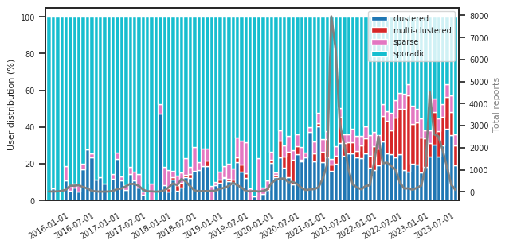

```python
entity = "Total"
level = 1

users_stats_view = qe.ppa_view_inflow(
    users_stats, f"custom_labels_{level}", entity=entity, freq="month"
)
# Overall diagram
viz_users_stats(users_stats_view, ticker_moltip=6)
```

The second hierarchical level, aggregated monthly, separates users into high-quality (upper figure) and low-quality (lower) categories for clearer visualization. It's evident that the surge in clustered users after the Spanish 2023 event is primarily driven by low-quality users, likely influenced by diverse communication channels. Despite their low quality, clustered users, being more engaged with the project and favoring spatial sampling, hold greater value compared to sporadic users. The latter are not shown in the figure since they are not partitioned by the quality measure due to low statistical support.

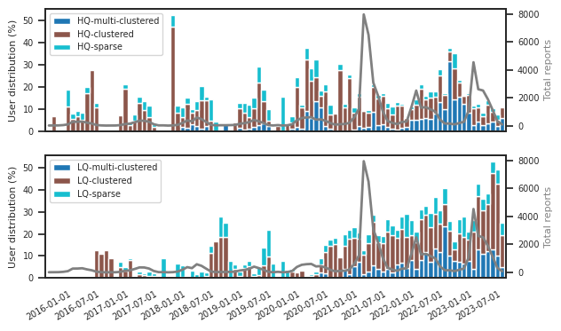

```python
level = 2
users_stats_view = qe.ppa_view_inflow(
    users_stats, f"custom_labels_{level}", entity=entity, freq="month"
)
viz_level_users_stats(users_stats_view, level, ticker_moltip=6, stacked=True)
```

The third hierarchical level, aggregated yearly, separates users into high-quality (upper figure) and low-quality (lower) categories for clearer visualization. This level further distinguishes between clustered and sparse users based on the spatial dispersion of their reports (labeled wide and narrow). Sparse users, adhering to a wider sampling pattern, contrast with the more balanced approach of clustered users. This result is directly dependent on the threshold level assigned to the spatial dispersion measure. Through yearly aggregation, it becomes apparent that high-quality sparse users decline following the EU scale-up, while conversely, low-quality sparse users increase.

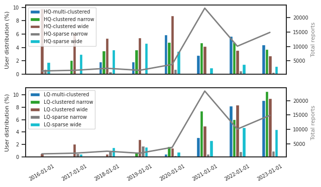

```python
level = 3
users_stats_view = qe.ppa_view_inflow(
    users_stats, f"custom_labels_{level}", entity=entity, freq="year"
)
viz_level_users_stats(users_stats_view, level, ticker_moltip=None, stacked=False)
```

### Netherlands user-profiling

The second hierarchical level, aggregated monthly, separates users into high-quality (upper figure) and low-quality (lower) categories for clearer visualization. The surge in clustered users following the Netherlands' surge event is evidently driven primarily by low-quality users. Subsequent to the main communication event, the persisting user base comprises predominantly clustered users, with sporadic users gradually diminishing as no further communication events engage them.

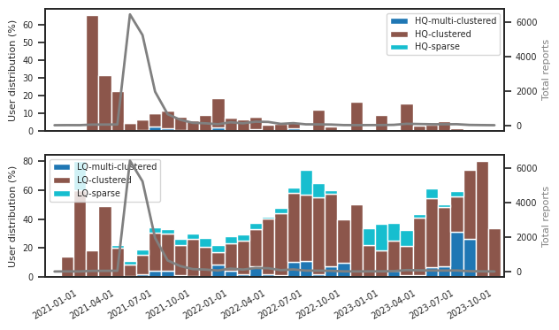

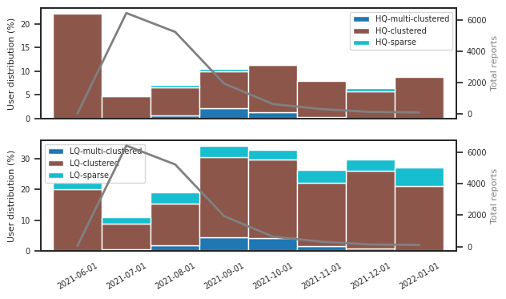

```python
entity = "Netherlands"
level = 2
users_stats_view = qe.ppa_view_inflow(
    users_stats, f"custom_labels_{level}", entity=entity, freq="month"
)
# Global picture
viz_level_users_stats(
    users_stats_view.loc["2021-01-01":, :], level, ticker_moltip=3, stacked=True
)
# Highlight of the surge event
viz_level_users_stats(
    users_stats_view.loc["2021-06-01":"2022-01-01"],
    level,
    ticker_moltip=None,
    stacked=True,
)
```

## Unsupervised profiling of users

Dimensional reduction and unsupervised clustering techniques are applied to obtain clusters of users, whose behavior depends on geo-location and participation quality. The analysis excludes sporadic users, as they contribute insignificantly and form a distinct user group. While the number of clusters (n_clusters) is discrete, the standard deviation of UTM coordinates (std_utm) is continuous. n_clusters are further discretized by grouping users with more than one cluster into a multi-cluster category, and a logarithmic transformation is applied to std_utm to facilitate and guide dimensional reduction. Level 3 heuristic labeling serves as a reference point to validate clusters resulting from the reduction process.

```python
users_stats["type_clusters"] = np.where(
    users_stats["n_clusters"] > 1, 2, users_stats["n_clusters"]
)

users_stats["log_std_utm"] = np.log(users_stats["std_utm"])
users_stats["log_std_utm"][users_stats["log_std_utm"] < 0] = 1

users_stats["custom_labels"] = users_stats["custom_labels_3"]
```

```
Raw feature transformation with umap-gower
```

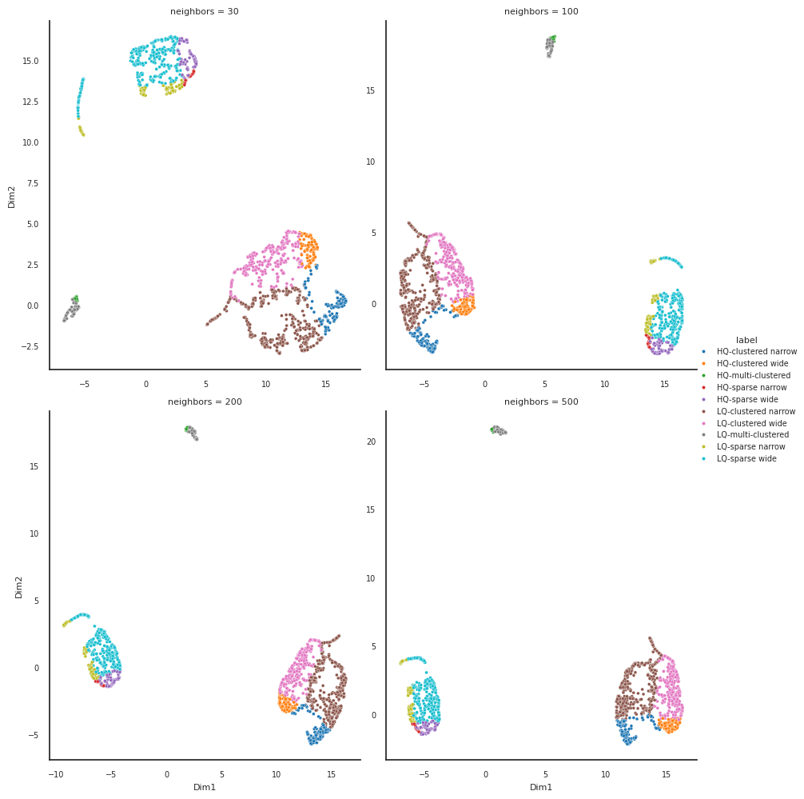

```
Raw feature transformation with tsne-gower
```

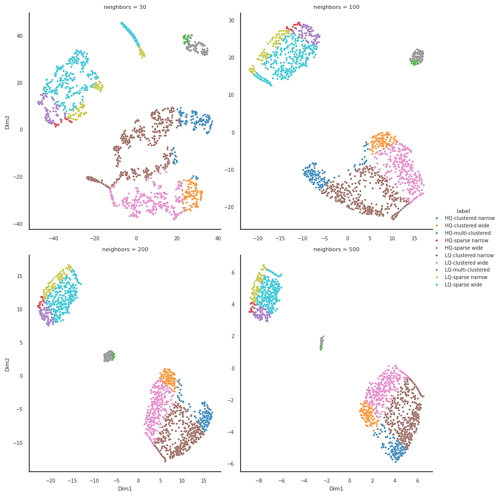

```python
feature_transformers = {
    "raw": None,
    # "l2": Normalizer(norm="l2")
    # "minmax": MinMaxScaler(feature_range=(0, 1)),
}
n_neighbors = [30, 100, 200, 500]
metric = "gower"
# metric = "euclidean"
# metric = "cosine"

if metric == "gower":
    cols = ["log_std_utm", "custom_labels_1", "quality"]
else:
    cols = ["log_std_utm", "type_clusters", "quality"]

if "custom_labels" not in (cols):
    cols_ = cols + ["custom_labels"]
else:
    cols_ = cols
users_stats_filt = users_stats.query("custom_labels != 'sporadic'")[cols_].fillna(0)


dimred_umap = dimred_screening(
    users_stats_filt, cols, "umap", metric, n_neighbors, feature_transformers
)
dimred_tsne = dimred_screening(
    users_stats_filt, cols, "tsne", metric, n_neighbors, feature_transformers
)
```

The number of clusters is selected after visual inspection of the 2D dimensional reduced space. Select reduction method for further analysis

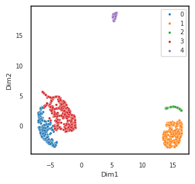

```python
tf_type = "raw"
dimred = dimred_umap[tf_type]
n_neighbors = 100

# Unsupervised clustering parameters
n_clusters = 5

Xft = dimred[0]
Xft_dist = dimred[1]
Xft_dimred = dimred[2].query("neighbors == @n_neighbors").iloc[:, :-2]
dimred_labels = SpectralClustering(
    n_clusters=n_clusters, random_state=RANDOM_STATE
).fit_predict(Xft_dimred)

p = sns.scatterplot(
    data=Xft_dimred, x="Dim1", y="Dim2", hue=dimred_labels, palette=PALETTE, s=8
)
p.figure.set_size_inches(WIDTH_FIG_HALFPAGE, 8 * CM)
```

After visual interpretation, we provide the correspondence between dimensional reduction clusters and user labels.

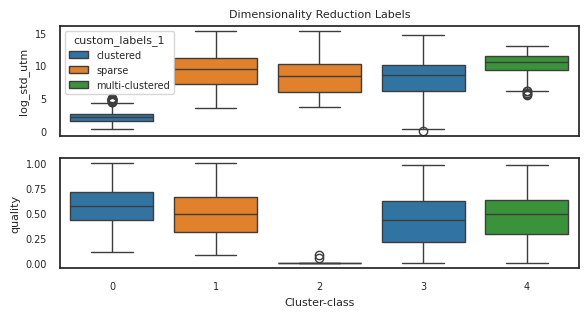

```python
labels_boxplot(users_stats_filt, dimred_labels, title="Dimensionality Reduction Labels")
dimred_labels_map = {
    4: "multi-clustered",
    0: "clustered narrow",
    3: "clustered wide",
    1: "HQ-sparse",
    2: "LQ-sparse",
}
```

For comparison, clustering is repeated but without dimensional reduction. Both approaches reach quite a similar result.

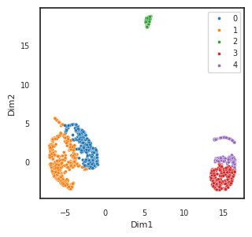

```python
cluster_labels = AgglomerativeClustering(
    n_clusters=n_clusters,
    linkage="average",
    metric="precomputed",
).fit_predict(Xft_dist)

p = sns.scatterplot(
    data=Xft_dimred, x="Dim1", y="Dim2", hue=cluster_labels, s=8, palette=PALETTE
)
p.figure.set_size_inches(WIDTH_FIG_HALFPAGE, 8 * CM)
```

As before, after visual interpretation, we provide the correspondence between agglomerative clusters and user labels.

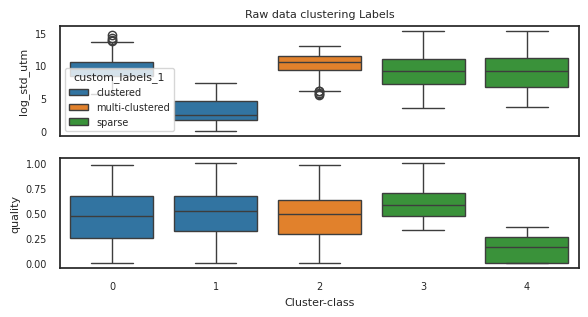

```python
labels_boxplot(users_stats_filt, cluster_labels, title="Raw data clustering Labels")
cluster_labels_map = {
    2: "multi-clustered",
    1: "clustered narrow",
    0: "clustered wide",
    3: "HQ-sparse",
    4: "LQ-sparse",
}
```

```python
users_stats_filt["dimred_labels"] = dimred_labels
users_stats_filt["cluster_labels"] = cluster_labels
users_stats_filt = users_stats_filt.replace(
    {"cluster_labels": cluster_labels_map, "dimred_labels": dimred_labels_map}
)
```

At this point, a visual examination of class distribution separation is feasible. Notably, the key distinction between dimensional reduction and direct clustering lies in their classification approach. Dimensional reduction categorizes LQ-sparse users as those with strictly zero quality, while direct clustering partitions users into LQ and HQ groups using a threshold quality value of 0.35. While dimensional reduction clustering offers clear delineation between LQ and HQ clusters, a softer partitioning with a more pragmatic threshold quality value is preferred in this context.

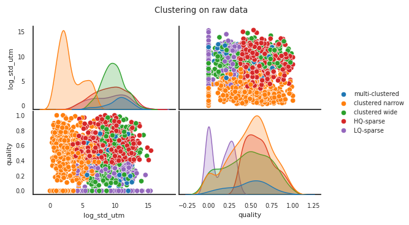

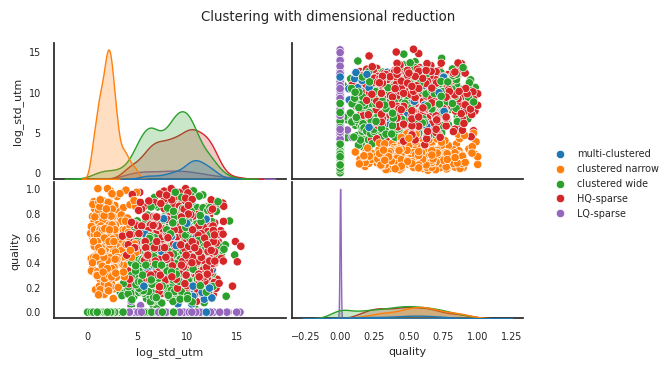

```python
order_col = list(cluster_labels_map.values())
for cluster_type, title in {
    "cluster_labels": "Clustering on raw data",
    "dimred_labels": "Clustering with dimensional reduction",
}.items():
    p = sns.pairplot(
        users_stats_filt,
        hue=cluster_type,
        hue_order=order_col,
        palette=PALETTE,
    )
    p.figure.set_size_inches(WIDTH_FIG_FULLPAGE, 8 * CM)
    p.figure.suptitle(title, y=1.08)
    p._legend.set_title(None)
```

### Overall MA-user temporal profiling

We can now visualize the temporal distribution of user contributions through report submissions. For this analysis, we utilize the labels obtained from clustering on raw data rather than employing a dimensional reduction procedure.

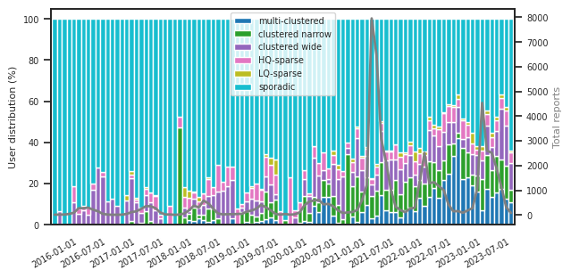

```python
users_stats["unsupervised_labels"] = users_stats_filt["cluster_labels"]
users_stats["unsupervised_labels"] = users_stats["unsupervised_labels"].fillna(
    "sporadic"
)
order_col.append("sporadic")
entity = "Total"
users_stats_view = qe.ppa_view_inflow(
    users_stats, "unsupervised_labels", entity=entity, freq="month"
)
viz_users_stats(users_stats_view[order_col], ticker_moltip=6)
```

### Spain users temporal profiling

Examining the exceptional surges in Spain (2023) and the Netherlands (2021), it becomes apparent that sporadic users are initially involved, but their contributions gradually diminish, giving way to the increased participation of multi-clustered and clustered users.

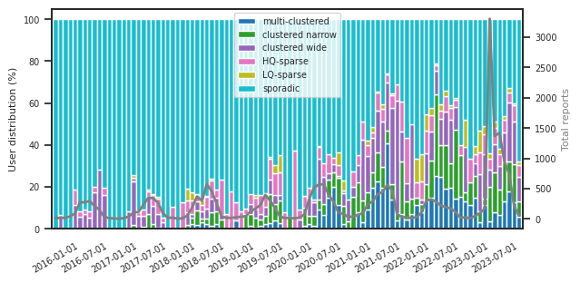

```python
entity = "Spain"
users_stats_view = qe.ppa_view_inflow(
    users_stats, "unsupervised_labels", entity=entity, freq="month"
)
viz_users_stats(users_stats_view[order_col], ticker_moltip=6)
```

### Netherlands users temporal profiling

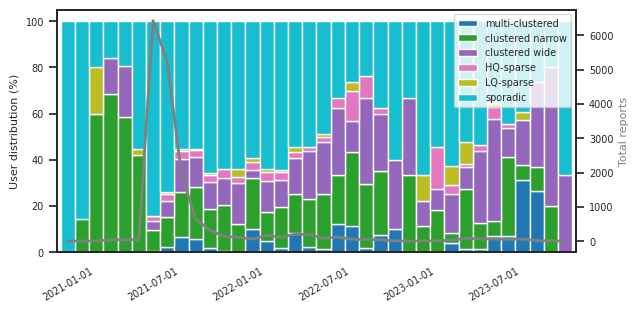

```python
entity = "Netherlands"
users_stats_view = qe.ppa_view_inflow(
    users_stats, "unsupervised_labels", entity=entity, freq="month"
)
viz_users_stats(users_stats_view[order_col].loc["2021-01-01":, :], ticker_moltip=6)
```